# Running multi-omics Integrating methods with CrIMMix

Morgane Pierre-Jean

2019-03-01

This vignette aims to show how to use the package named `CrIMMix`. This package groups several R packages that perform integrating analysis of multi-omics datasets. In this package, we can also simulate data in order to perform a comparative analysis with existent packages.

# Simulate Datasets

It is possible to tune the number of clusters, the number of samples per clusters, the length of signals. Then, the users can define the distribution of the data between the normal, the binary, or the uniform distribution.

## Normal distribution

The simulation under normal distribution could represent for instance gene expression data or raw copy number signal. For each cluster, the user can choose the mean and the variance of the distribution that varies from a cluster to another. The user can also choose the proportion of variables affected by this modified distribution. To finish, it is possible to modify the background noise.

```r
set.seed(34)
c_1 <- simulateY(nclust=4, n_byClust=20, J=100, flavor="normal", params=list(c(mean=3,sd=1)), prop=0.1, noise=1)
```

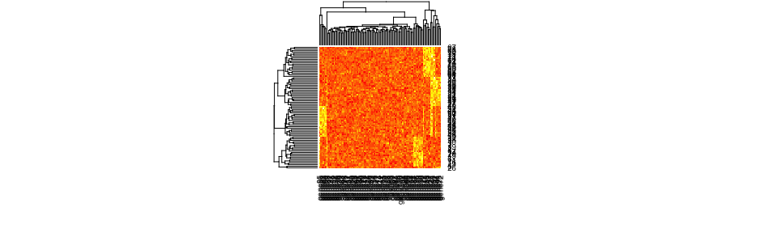

```r
heatmap(c_1$data)
```

## Binary distribution

The simulation under binary distribution could represent for instance mutations in tumor samples. For each cluster, the user can choose the mutation rate that varies from a cluster to another. The user can also choose the proportion of variables affected by this modified distribution. To finish, it is possible to modify the background noise (added random mutation at a proportion equal to the noise).

```r
set.seed(34)
c_2 <- simulateY(nclust=4, n_byClust=20, J=100, flavor="binary", params=list(c(p=0.7)), prop=0.1, noise=0.1)
```

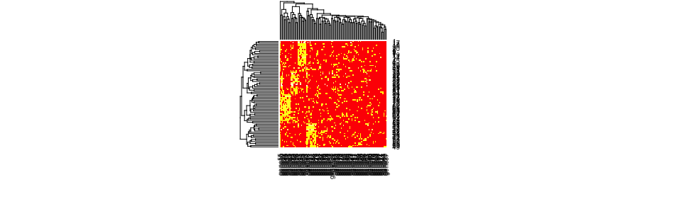

```r
heatmap(c_2$data)
```

## Beta distribution

```r
set.seed(34)
params_beta <- list(c(mean1=-2, mean2=2, sd1=0.5, sd2=0.5))
c_3 <- simulateY(nclust=4, n_byClust=20, J=500,flavor="beta", params=params_beta, prop=0.2, noise=1)
```

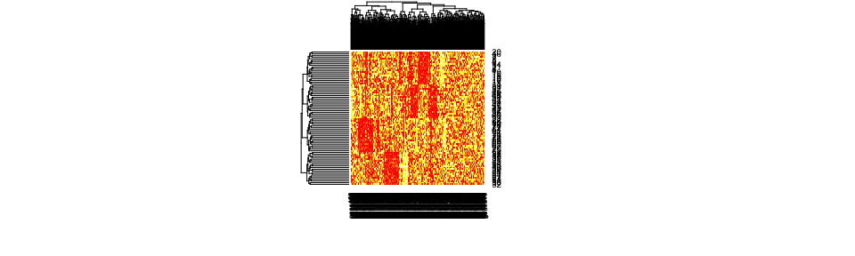

```r
heatmap(c_3$data)
```

# Run Integrative methods with CrIMMix

```r
data <- list(c_1$data, c_2$data, c_3$data)
```

## Run Mocluster

```r
res_Mocluster <- IntMultiOmics(data, K=4, method="Mocluster", k=c(0.2, 0.2, 0.4))
```

## Run RGCCA

```r
res_RGCCA <- IntMultiOmics(data, K=4, method="RGCCA")
```

## Run iCluster

```r
res_icluster <- IntMultiOmics(data, K=4, method="iCluster", type=c("gaussian", "binomial", "gaussian"), lambda=c(0.01, 0.01, 0.005))
```

# Performance Evaluation

## Clustering evaluation with ARI

```r
adjustedRIComputing(res_Mocluster,c_1$true.clusters)
```

```
#> [1] 1
```

```r
adjustedRIComputing(res_RGCCA,c_1$true.clusters)
```

```
#> [1] 0.721469
```

```r
adjustedRIComputing(res_icluster,c_1$true.clusters)
```

```
#> [1] 0.9102489
```

## ROC evaluation

```r
trueDat1 <- c_1$positive %>% unlist %>% unique
trueDat2 <- c_2$positive %>% unlist %>% unique
trueDat3 <- c_3$positive %>% unlist %>% unique
truth <- list(trueDat1,trueDat2, trueDat3)
```

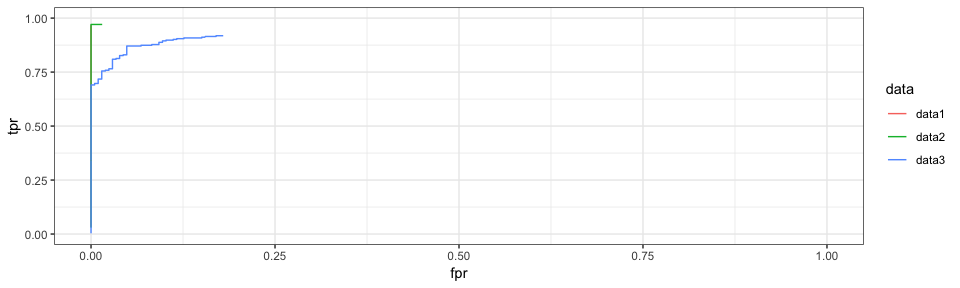

```r
roc_moclust <- roc_eval(truth= truth, fit = res_Mocluster$fit, method = "Mocluster")
plot_roc_eval(roc_moclust)
```